# Longitudinal Evaluation of FEV1 Changes and Treatment Efficacy in Patients with Chronic Obstructive Pulmonary Disease

A Mixed Model for Repeated Measures Approach

Abderrezzaq KADOUCHE

## **Introduction**

Chronic Obstructive Pulmonary Disease (COPD) is a progressive, life-threatening lung condition characterized by chronic airflow limitation and persistent respiratory symptoms.

In clinical development, the primary endpoint for evaluating the efficacy of new therapeutic agents is the Forced Expiratory Volume in 1 second (FEV1), expressed as a percentage of the predicted normal value.

FEV1 measures how quickly the lungs can be emptied. Low levels of FEV1 serve as a crucial clinical indicator for the severity and progression of COPD. A continuous decline in FEV1 reflects structural lung damage, whereas stabilization or improvement in FEV1 trajectories indicates a positive therapeutic response.

## **Objective**

Pulmonary function was assessed longitudinally across multiple post-baseline clinical visits to address the primary research question :

Does the investigational treatment significantly slow down or reverse the decline of FEV1 over time compared to placebo ?

## **Study Design and Data**

This project utilizes a validated artificial dataset consisting of 800 subjects tracked across multiple clinical visits. While artificial, this dataset is meticulously structured under industry-standard CDISC ADaM specifications.

The data simulates a randomized, double-blind, placebo-controlled parallel-group trial where patients were randomized to receive either the active investigational drug or a placebo.

## **Variable Specifications**

- USUBJID: subject ID.
- AVISIT: visit number.
- ARMCD: treatment, TRT or PBO.
- RACE: 3-category race.
- SEX: sex.
- FEV1_BL: FEV1 at baseline (%).
- FEV1: FEV1 at study visits.
- WEIGHT: weighting variable.
- VISITN: integer order of the visit.
- VISITN2: coordinates of the visit for distance calculation.

## **Descriptive Analysis of Continuous Variables**

```r
library(prettyR)
vars_quanti <- c("FEV1_BL", "FEV1")
describe(
fev_data[, vars_quanti],
num.desc = c("min", "max", "mean", "median", "sd", "valid.n")
)
```

```
## Description of fev_data[, vars_quanti]
```

```
##
##  Numeric
##           min   max  mean median   sd valid.n
## FEV1_BL 14.34 60.24 40.19  40.30 9.12     800
## FEV1    19.28 84.08 42.30  41.86 9.32     537
```

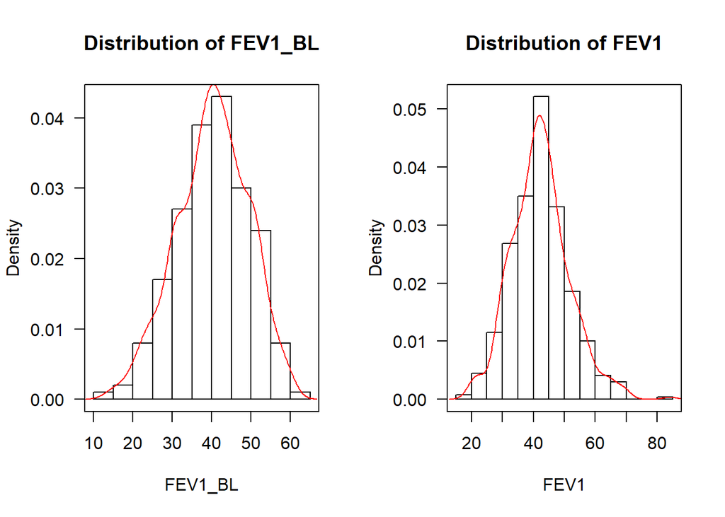

```r
par(mfrow = c(1, 2))
# Boucle sur toutes les variables quantitatives avec courbe de densité

for (var in vars_quanti) {
# 1. Tracer l'histogramme en mode "densité de probabilité" (prob = TRUE)
hist(fev_data[[var]],
main = paste("Distribution of", var), # Titre dynamique
xlab = var,                           # Nom de la variable sur l'axe X
ylab = "Density",                     # L'axe Y devient la Densité
las  = 1,  # Labels horizontaux
col  = "white",                       # Barres blanches
border = "black",                     # Contours noirs
prob = TRUE)                          # OBLIGATOIRE pour la densité
# 2. Calculer et superposer la courbe de densité
# na.rm = TRUE est crucial car il peut y avoir des NA dans la colonne 'nodes'
lines(density(fev_data[[var]], na.rm = TRUE),
col = "red",                         # Courbe en rouge pour le contraste
lwd = 1)                             # Épaisseur de la ligne
# 3. AJOUT DU CADRE AUTOUR DU GRAPHIQUE
box(col = "black", lwd = 1)
}
```

## **Descriptive Analysis of Categorical Variables**

```r
library(gtsummary)
library(dplyr)
fev_data %>%
select(ARMCD, SEX, RACE) %>%
tbl_summary(
by = ARMCD,
statistic = all_categorical() ~ "{n} ({p}%)",
digits    = all_categorical() ~ list(0, 1),
missing_text = "Missing"
) %>%
bold_labels()
```

| **Characteristic** | **PBO** N = 420<sup>1</sup> | **TRT** N = 380<sup>1</sup> |
| --- | --- | --- |
| SEX |  |  |
| Male | 200 (47.6%) | 176 (46.3%) |
| Female | 220 (52.4%) | 204 (53.7%) |
| RACE |  |  |
| Asian | 152 (36.2%) | 128 (33.7%) |
| Black or African American | 184 (43.8%) | 116 (30.5%) |
| White | 84 (20.0%) | 136 (35.8%) |

<sup>1</sup> n (%)

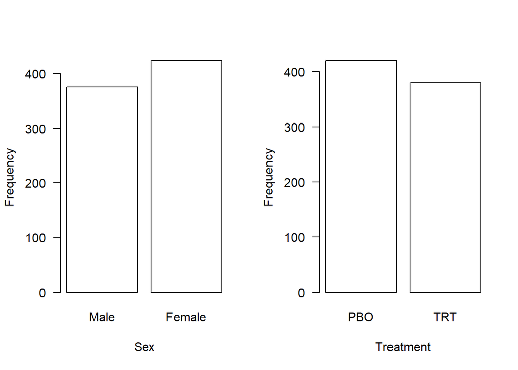

```r
par(mfrow = c(1, 2))

# ── 1. SEX (Sexe) ──────────────────────────────────────
barplot(
  table(fev_data$SEX),
  ylab      = "Frequency",
  xlab      = "Sex",
  col       = "white",
  border    = "black",
  las       = 1,
  cex.names = 1.0,
  cex.lab   = 1.0
)

# ── 2. TRT / PBO ───────────
barplot(
  table(fev_data$ARMCD),
  ylab      = "Frequency",
  xlab      = "Treatment",
  col       = "white",
  border    = "black",
  las       = 1,
  cex.names = 1.0,
  cex.lab   = 1.0
)
```

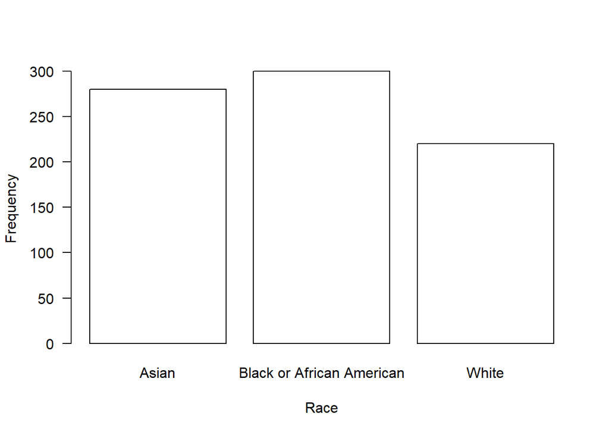

```r
# ── 3. RACE ───────────────
barplot(
  table(fev_data$RACE),
  ylab      = "Frequency",
  xlab      = "Race",
  col       = "white",
  border    = "black",
  las       = 1,
  cex.names = 1.0,
  cex.lab   = 1.0
)
```

## **Missing data**

The primary outcome, FEV1, presents a missing data rate of 32.88% (263 missing observations), while all baseline covariates and operational variables remain fully observed. In alignment with standard clinical trial methodology for longitudinal data, these missing values are assumed to follow a Missing At Random (MAR) mechanism.

```r
tab_NA <- data.frame(
  Variables = names(fev_data),
  n_NA = colSums(is.na(fev_data)),
  percent_NA = round(colMeans(is.na(fev_data)) * 100, 2),
  row.names = NULL )

print(tab_NA)
```

```
##    Variables n_NA percent_NA
## 1    USUBJID    0       0.00
## 2     AVISIT    0       0.00
## 3      ARMCD    0       0.00
## 4       RACE    0       0.00
## 5        SEX    0       0.00
## 6    FEV1_BL    0       0.00
## 7       FEV1  263      32.88
## 8     WEIGHT    0       0.00
## 9     VISITN    0       0.00
## 10   VISITN2    0       0.00
```

## **Statistical Modeling and Diagnostics**

A Mixed Model for Repeated Measures (MMRM) estimated via Restricted Maximum Likelihood (REML) is applied. This framework naturally accounts for the missing observations without the need for explicit or artificial data imputation, ensuring unbiased and efficient treatment effect estimates. To evaluate the robustness of this assumption, relevant sensitivity analyses will be conducted.

The assumption of normality for the MMRM residuals is fully satisfied.

```r
# Ajustement du modèle MMRM
fit_mmrm <- mmrm(
  formula = FEV1 ~ FEV1_BL + ARMCD * AVISIT + us(AVISIT | USUBJID),
  data = fev_data
)
```

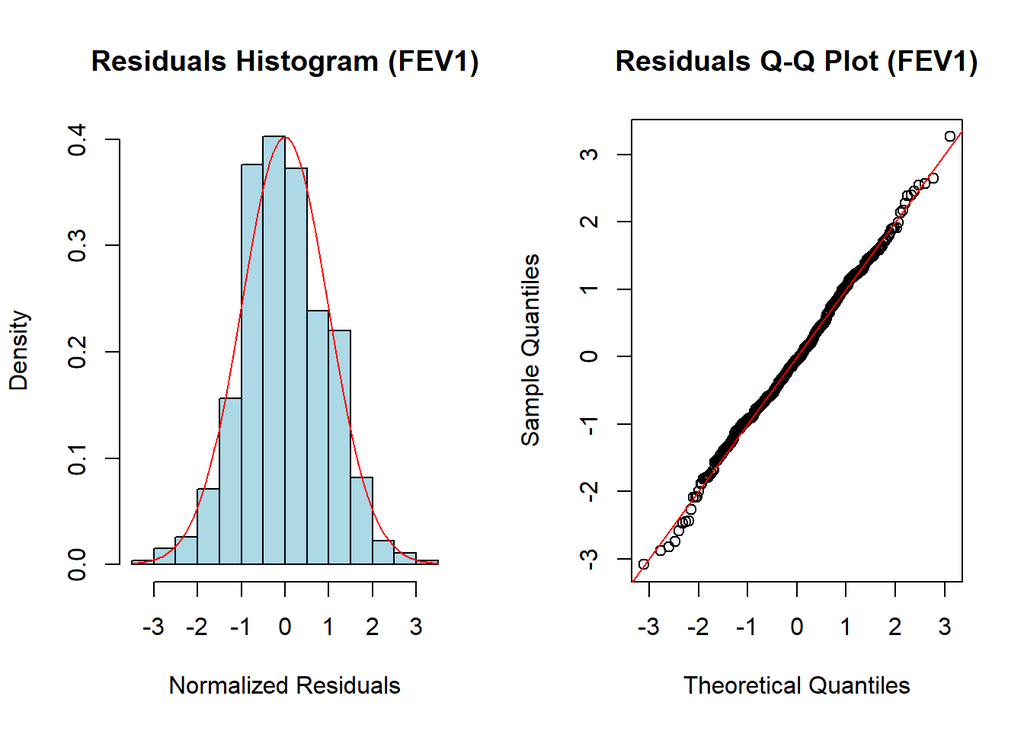

```r
# Check the normal distribution of model residuals using HISTOGRAM & Q-Q PLOT:

# 1. Extract residuals from your mmrm model (adjusted for covariance structure)
residus <- residuals(fit_mmrm, type = "normalized")

# 2. Configure R to display 2 plots side-by-side
par(mfrow = c(1, 2))

# 3. PLOT 1: The Histogram
hist(residus,
     probability = TRUE,
     col = "lightblue",
     main = "Residuals Histogram (FEV1)",
     xlab = "Normalized Residuals",
     ylab = "Density")

# Add the red theoretical normal curve on top
curve(dnorm(x, mean = mean(residus, na.rm = TRUE), sd = sd(residus, na.rm = TRUE)),
      col = "red", lwd = 1, add = TRUE)

# 4. PLOT 2: The Q-Q Plot
qqnorm(residus,
       main = "Residuals Q-Q Plot (FEV1)",
       xlab = "Theoretical Quantiles",
       ylab = "Sample Quantiles")
qqline(residus, col = "red", lwd = 1) # Add the red reference line
```

# **Results**

Patients in the investigational treatment arm (TRT) maintained consistently higher adjusted mean FEV1 values compared to the placebo arm (PBO) throughout the study duration.

At Visit 1, the adjusted mean FEV1 was 37.3 (95% CI: 35.7, 38.8) for the TRT group compared to 32.6 (95% CI: 31.1, 34.1) for the PBO group. This therapeutic advantage remained stable across subsequent timepoints, with estimated differences between groups of +4.4 units at Visit 2, +3.5 units at Visit 3, and +5.0 units at the final visit (Visit 4: TRT mean = 53.0 [95% CI: 50.6, 55.4] vs. PBO mean = 48.0 [95% CI: 45.6, 50.4]).

Overall, these results demonstrate a sustained parallel improvement in both treatment groups rather than a progressive divergence over time.

```r
library(emmeans)

# 1. Calculer les moyennes ajustées par traitement et par visite
lsmeans_ev <- emmeans(fit_mmrm, ~ ARMCD | AVISIT)
print(lsmeans_ev)
```

```
## AVISIT = VIS1:
##  ARMCD emmean    SE  df lower.CL upper.CL
##  PBO     32.6 0.766 144     31.1     34.1
##  TRT     37.3 0.780 143     35.7     38.8
##
## AVISIT = VIS2:
##  ARMCD emmean    SE  df lower.CL upper.CL
##  PBO     37.5 0.604 149     36.3     38.7
##  TRT     41.9 0.599 146     40.7     43.0
##
## AVISIT = VIS3:
##  ARMCD emmean    SE  df lower.CL upper.CL
##  PBO     43.0 0.513 131     41.9     44.0
##  TRT     46.5 0.566 132     45.4     47.6
##
## AVISIT = VIS4:
##  ARMCD emmean    SE  df lower.CL upper.CL
##  PBO     48.0 1.210 135     45.6     50.4
##  TRT     53.0 1.210 134     50.6     55.4
##
## Confidence level used: 0.95
```

```r
# 2. Obtenir le contraste (la différence entre les bras) à chaque visite
contrasts_ev <- pairs(lsmeans_ev, reverse = TRUE) # reverse = TRUE pour faire Traitement - Placebo
print(contrasts_ev)
```

```
## AVISIT = VIS1:
##  contrast  estimate    SE  df t.ratio p.value
##  TRT - PBO     4.66 1.090 144   4.266  <.0001
##
## AVISIT = VIS2:
##  contrast  estimate    SE  df t.ratio p.value
##  TRT - PBO     4.37 0.851 148   5.136  <.0001
##
## AVISIT = VIS3:
##  contrast  estimate    SE  df t.ratio p.value
##  TRT - PBO     3.57 0.763 131   4.672  <.0001
##
## AVISIT = VIS4:
##  contrast  estimate    SE  df t.ratio p.value
##  TRT - PBO     5.01 1.710 134   2.936  0.0039
```

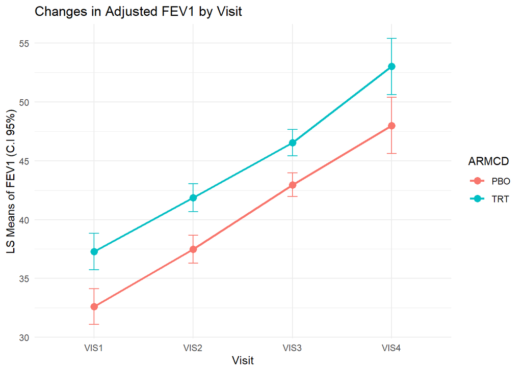

```r
library(ggplot2)

# Convertir les LS Means en dataframe pour ggplot
df_plot <- as.data.frame(lsmeans_ev)

ggplot(df_plot, aes(x = AVISIT, y = emmean, group = ARMCD, color = ARMCD)) +
  geom_line(linewidth = 1) +
  geom_point(size = 3) +
  geom_errorbar(aes(ymin = lower.CL, ymax = upper.CL), width = 0.1) +
  theme_minimal() +
  labs(title = "Changes in Adjusted FEV1 by Visit",
       x = "Visit", y = "LS Means of FEV1 (C.I 95%)")
```

# **Sensitivity Analysis**

To evaluate the impact of missing data (32.88% of FEV1 observations), a sensitivity analysis was conducted by restricting the dataset strictly to patients who completed all four post-baseline visits (Complete Case Analysis).

The results demonstrated exceptional robustness, as the therapeutic benefit of the investigational treatment remained statistically significant at every single timepoint. At Visit 1, the adjusted treatment effect was 6.09 units (p = 0.0023). This significant advantage persisted through Visit 2 (Difference = 4.58, p = 0.0134) and Visit 3 (Difference = 5.41, p = 0.0004).

At the final visit (Visit 4), the treatment group exhibited a substantial superiority of 9.92 units in adjusted mean FEV1 over the placebo group. Despite a noticeable increase in standard error (SE = 3.97) and a reduction in degrees of freedom (df = 36.9) due to the exclusion of incomplete profiles, the treatment effect remained fully significant (p = 0.0171).

These findings confirm that the primary efficacy conclusions are highly reliable and robust.

```r
# 1. Identifier les patients qui ont des données à TOUTES les visites
complete_subjects <- names(which(table(fev_data$USUBJID[!is.na(fev_data$FEV1)]) == 4))

# 2. Filtrer le jeu de données
data_complete <- subset(fev_data, USUBJID %in% complete_subjects)

# 3. Refaire tourner le MMRM sur ce sous-groupe
fit_sens_complete <- mmrm(
  formula = FEV1 ~ FEV1_BL + ARMCD * AVISIT + us(AVISIT | USUBJID),
  data = data_complete
)

# 4. Vérifier les nouveaux contrastes
pairs(emmeans(fit_sens_complete, ~ ARMCD | AVISIT), reverse = TRUE)
```

```
## AVISIT = VIS1:
##  contrast  estimate   SE   df t.ratio p.value
##  TRT - PBO     6.09 1.86 36.9   3.268  0.0023
##
## AVISIT = VIS2:
##  contrast  estimate   SE   df t.ratio p.value
##  TRT - PBO     4.58 1.77 36.9   2.596  0.0134
##
## AVISIT = VIS3:
##  contrast  estimate   SE   df t.ratio p.value
##  TRT - PBO     5.41 1.40 36.7   3.871  0.0004
##
## AVISIT = VIS4:
##  contrast  estimate   SE   df t.ratio p.value
##  TRT - PBO     9.92 3.97 36.9   2.498  0.0171
```

# **Conclusion**

The primary MMRM analysis demonstrated a highly significant, rapid, and sustained therapeutic benefit for the investigational treatment group (TRT) compared to the placebo group (PBO). Patients receiving the active drug exhibited a clinically meaningful improvement of +4.66 FEV1 units at the very first post-baseline visit (p < 0.0001). This therapeutic window remained remarkably stable and statistically solid across all subsequent timepoints, culminating in a +5.01 FEV1 unit superiority over placebo at the final evaluation (Visit 4, p = 0.0039). The parallel nature of the treatment trajectories indicates that while the drug does not progressively accelerate lung function recovery over time, it establishes and maintains a powerful and durable protective shift in respiratory capacity.

Furthermore, the Complete Case sensitivity analysis fully corroborated these findings, where the treatment effect remained statistically significant at every visit and even increased in magnitude (+9.92 units at Visit 4, p = 0.0171) among trial completers.

In conclusion, the investigational treatment represents a highly effective therapeutic strategy for COPD management.